# Semantic Image Segmentation - Part 1

## Deep Learning Methods for Semantic Segmentation

So far, you have seen image classification, where the task of the network is to assign a label or class to an input image. However, suppose you want to know where an object is located in the image, what shape that object is, which pixel belongs to which object, etc. In this case, you will want to segment the image, i.e., give each pixel in the image a label. So, the task of image segmentation is to train a neural network to produce a pixel-wise mask of the image. This helps in understanding the image at a much lower level, i.e., the pixel level. Image segmentation has many applications in medical imaging, self-driving cars, and satellite imagery, to name a few.

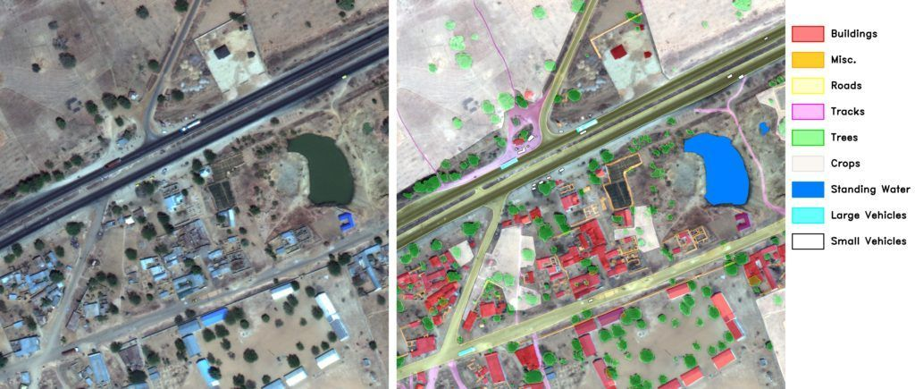

More precisely, semantic image segmentation is the task of labeling each pixel in the image into a predefined set of classes. For example, various objects like cars, trees, people, traffic signs, etc. can be used as classes for semantic image segmentation. So, the task is to take an image (RGB or grayscale) and produce a W x H x 1 matrix, where W and H represent the width and height of the image, respectively. Each cell in this matrix would contain the predicted class IDs for each pixel in the image.

### Image Classification vs. Semantic Segmentation

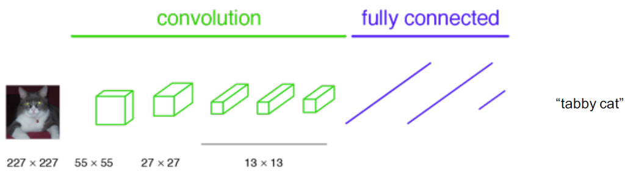

When it comes to semantic segmentation, we usually don’t require a fully connected layer at the end because our goal is not to predict the class label of the image.

In semantic segmentation, our goal is to extract features before using them to separate the image into multiple segments.

However, the problem with convolutional networks is that the image size gets reduced as it passes through the network due to the max-pooling layers.

To efficiently separate the image into multiple segments, we need to upsample using an interpolation technique, which is achieved using deconvolutional layers.

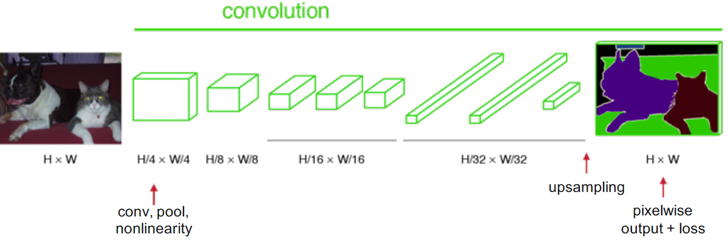

### Labels in Semantic Segmentation

In deep learning, we express categorical class labels as one-hot encoded vectors. Similarly, in semantic segmentation, we can express the output matrix using a one-hot encoding scheme by essentially creating a channel for each class label and marking the cells by 1 that contain the pixel of the corresponding class and marking the remaining cells by 0.

[figure not shown]

## Implementing a Semantic Segmentation Architecture

Like other computer vision tasks, using a CNN for semantic segmentation would be the obvious choice. When using CNN for semantic segmentation, the output would be an image with the same resolution as the input, unlike a fixed-length vector in the case of image classification.

A naive approach to building a neural network architecture for this task is to simply stack multiple convolutional layers (with the same padding to preserve dimensions) and output a final segmentation map. This directly learns a mapping from the input image to its corresponding segmentation through successive transformation of feature mappings; however, it is quite computationally expensive to preserve full resolution across the network.

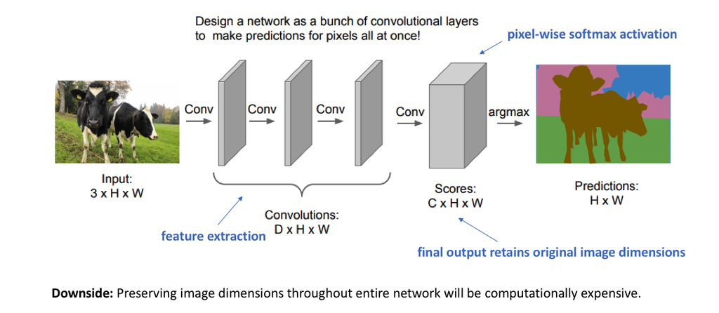

Recall that for deep convolutional networks, earlier layers tend to learn low-level concepts, while later layers develop more high-level (and specialized) feature mappings. To maintain expressiveness, we typically need to increase the number of feature maps (channels) as we go deeper into the network. This is not necessarily a problem for the task of image classification, since for that task we only care about what the image contains (and not where it is located). Thus, we could alleviate the computational burden by periodically downsampling our feature maps via pooling or strided convolutions (i.e., compressing the spatial resolution) without worrying. However, for image segmentation, we would like our model to produce a full-resolution semantic prediction. A popular approach for image segmentation models is to follow an encoder/decoder framework where we reduce the spatial resolution of the input, developing lower resolution feature mappings that are highly efficient at discriminating between classes, and up-resolution the feature representations into a full resolution segmentation map.

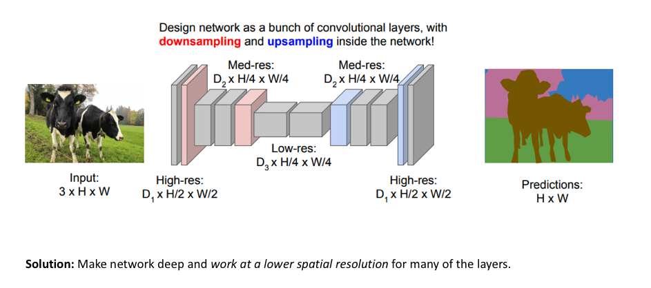

## Methods for upsampling:

There are a few different approaches we can use to increase the resolution of a feature map. While pooling operations decrease resolution by summarizing a local area with a single value (i.e., average or max pooling), unpooling operations increase resolution by distributing a single value across a higher resolution.

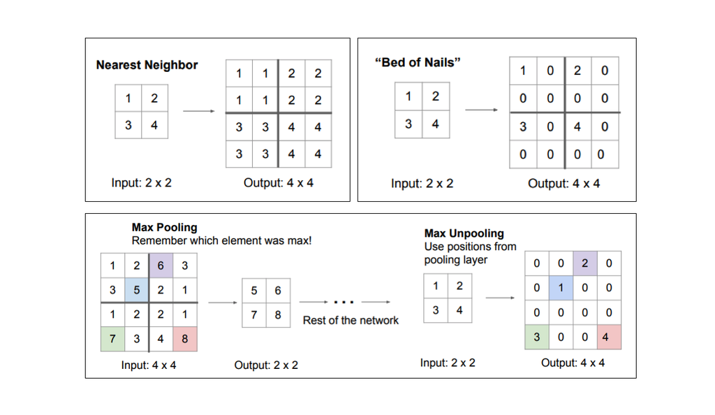

However, transposed convolutions are by far the most popular approach as they allow us to build on learned upsampling.

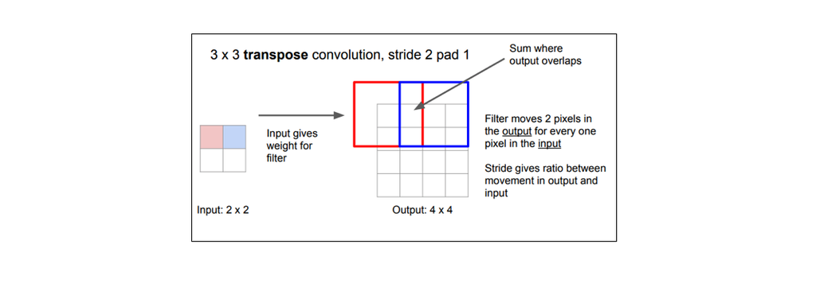

Whereas a typical convolution operation will take the dot product of the values currently in the filter view and produce a single value for the corresponding output position, a transposition convolution essentially does the opposite. For a transposition convolution, we take a single value from the low-resolution feature map and multiply all of the weights in our filter by that value, projecting those weighted values onto the output feature map.

For filter sizes that produce an overlap in the output feature map (e.g. 3x3 filter with stride 2 - as shown in the example below), the overlapping values are simply summed. Unfortunately, this tends to produce a checkerboard artifact in the output and is undesirable, so it is best to ensure that the filter size does not produce an overlap.

## Loss Functions for Semantic Segmentation

The loss function is used to guide the neural network towards optimization. Let’s discuss some popular loss functions for the semantic segmentation task. Semantic segmentation models usually use a simple categorical entropy loss function during training. However, if you are interested in getting the granular information of an image, you will need to revert to slightly more advanced loss functions.

### Distribution-based loss

#### Cross Entropy Loss

The most commonly used loss function for the image segmentation task is a pixel-wise cross-entropy loss. This loss examines each pixel individually, comparing the class predictions (pixel depth vector) with our one-hot encoded target vector.

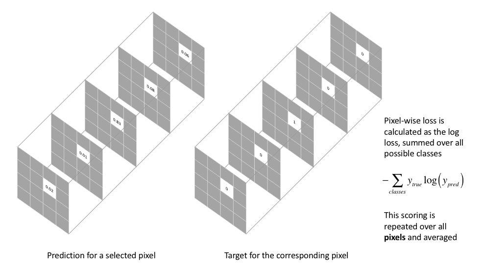

Since the cross-entropy loss evaluates the class predictions for each pixel vector individually and then averages them across all pixels, we are essentially asserting equal learning for each pixel in the image. This can be a problem if your various classes have an imbalanced representation in the image, as training may be dominated by the most prevalent class. Long et al. (FCN paper) discusses weighting this loss for each output channel in order to counteract a class imbalance present in the dataset.

#### Weighted cross entropy

It is an extension of the CE, which assigns different weights to each class. In general, classes not presented will have higher weights.

### Focal Loss

It adapts the CE pattern to handle extreme foreground-background class imbalance, where the loss attributed to well-classified examples is reduced.

### Region-based Loss

Region-based loss functions aim to minimize the mismatch or maximize the overlapping regions between the ground truth and the predicted segmentation.

### Dice Loss

The Dice function is nothing but the F1 score. This loss function directly tries to optimize the F1 score. Similarly, the direct IOU score can also be used to perform optimization

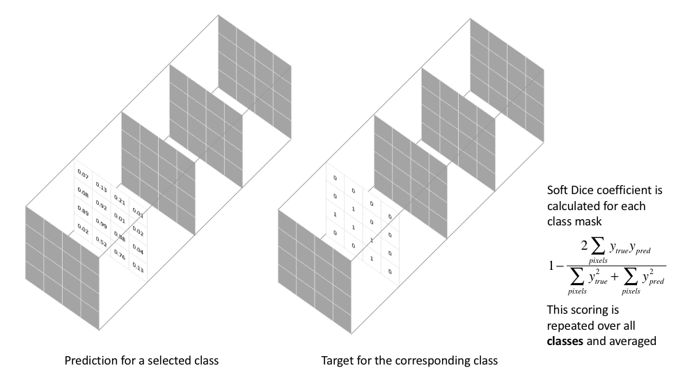

### IoU Loss

IoU Loss (also called Jaccard Loss), similar to Dice Loss, is also used to directly optimize the targeting metric.

#### Tversky loss

Sets different weights for false negative (FN) and false positive (FP), which is different from data loss using equal weights for FN and FP.

#### Focal Tversky loss

Applies the concept of focal loss to focus on difficult cases with low probabilities.

## Metricas para Segmentação Semântica

Let's discuss the metrics that are commonly used to understand and evaluate the results of a model.

### Pixel Accuracy

Pixel accuracy is the most basic metric that can be used to validate the results. Accuracy is obtained by taking the proportion of correctly classified pixels to the total pixels

Accuracy = (TP+TN)/(TP+TN+FP+FN)

The main drawback of using this technique is that the result may look good if one class dominates the other. Say, for example, the background class covers 90% of the input image, we can achieve 90% accuracy just by classifying every pixel as background

### Metrics based on IoU

Intuitively, a successful prediction is one that maximizes the overlap between the predicted and true objects. Two related but different metrics for this goal are the Dice and Jaccard coefficients (or indices):

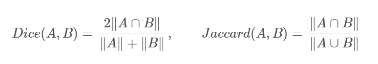

IOU is defined as the ratio of the intersection of the ground truth and predicted segmentation outputs over their union. If we are calculating for multiple classes, then the IOU of each class is calculated and its average is taken. It is a better metric compared to pixel-wise accuracy because if each pixel is given as background in a 2-class input, then the IOU value is (90/100+0/100)/2 i.e. 45% IOU which gives a better representation compared to 90% accuracy.

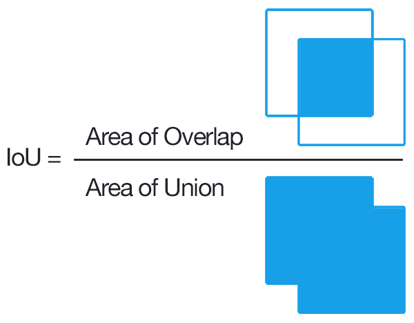

In terms of the confusion matrix, the metrics can be reformulated in terms of true/false positives/negatives:

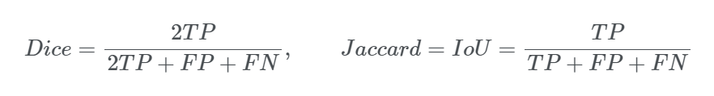

Here is an illustration of the Dice and IoU metrics given two circles representing the ground truth and predicted masks for an arbitrary object class:

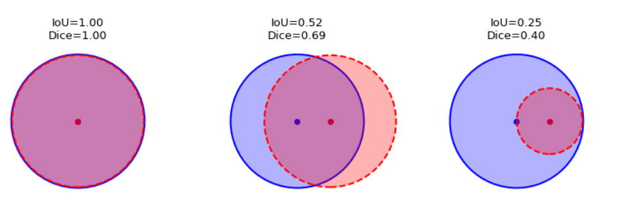

### Frequency weighted IOU

This is an extension on top of the average IOU we discussed and is used to combat class imbalance. If a class dominates most of the images in a dataset, such as background, it needs to be weighted compared to other classes. So, instead of taking the average of all the results for the class, a weighted average is taken based on the frequency of the region of the class in the dataset.

## FCN - Fully Convolutional Networks

The general architecture of a CNN consists of a few convolutional and pooling layers followed by a few fully connected layers at the end. The Fully Convolutional Network paper released in 2014 argues that the final fully connected layer can be thought of as doing a 1x1 convolution that covers the entire region.

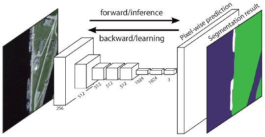

Thus, the final dense layers can be replaced with a convolution layer achieving the same result. But now the advantage of doing so is that the input size no longer needs to be fixed. By involving dense layers, the input size is restricted and hence when a different size input is to be provided, it has to be resized. But by replacing a dense layer with convolution, this restriction does not exist.

Furthermore, when a larger size of image is provided as input, the output produced will be a feature map and not just a class output as for a normal input size image. Furthermore, the observed behavior of the final feature map represents the heatmap of the required class, i.e. the position of the object is highlighted in the feature map. Since the output of the feature map is a heatmap of the required object, it is valid information for our segmentation use case.

Since the feature map obtained at the output layer is a downsampled due to the set of convolutions performed, we would like to upsample it using an interpolation technique. Bilinear upsampling works, but the paper proposes using learned upsampling with deconvolution, which can even learn nonlinear upsampling.

The downsampling part of the network is called the encoder, and the upsampling part is called the decoder. This is a pattern we will see in many architectures, namely downsampling with the encoder and then upsampling with the decoder. In an ideal world, we would not want to downsample using pooling and keep the same size, but this would lead to a huge amount of parameters and would be computationally infeasible.

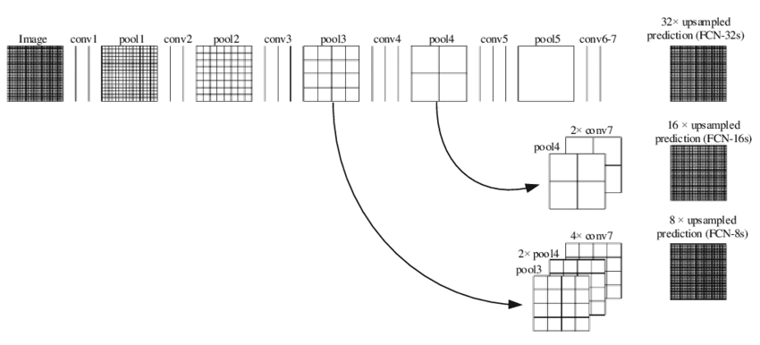

Although the output results obtained were decent, the observed output is rough and not smooth. The reason for this is the loss of information in the final feature layer due to 32x downsampling using convolutional layers. Now it becomes very difficult for the network to do 32x upsampling using this little information. This architecture is called FCN-32

To solve this problem, the paper proposed 2 other architectures FCN-16, FCN-8. In FCN-16, the information from the previous pooling layer is used along with the final feature map and hence now the task of the network is to learn 16x upsampling which is better as compared to FCN-32. FCN-8 tries to make it even better by including information from one more previous pooling layer.

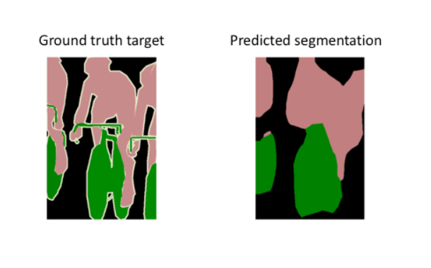

## Use Case: Usage and Coverage Class Segmentation

Let's start with an example using the Landcover AI dataset:

The LandCover.ai (Land Cover from Aerial Imagery) dataset is a dataset for automatic mapping of buildings, forests, water and roads from aerial imagery.

Dataset features

- land cover of Poland, Central Europe 1
- three spectral bands - RGB
- 33 orthophotos with 25 cm pixel resolution (~9000x9500 px)
- 8 orthophotos with 50 cm pixel resolution (~4200x4700 px)
- total area of 216.27 km2

Dataset format

- rasters are three-channel GeoTiffs with EPSG:2180 spatial reference system
- masks are single-channel GeoTiffs with EPSG:2180 spatial reference system

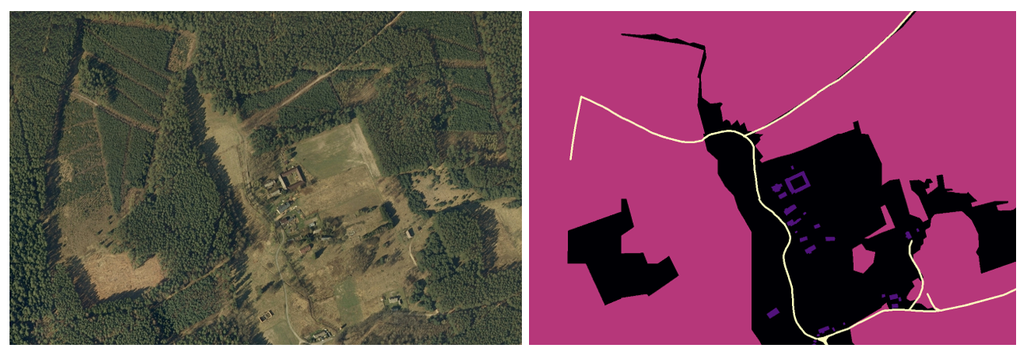

```python
from google.colab import drive
drive.mount('/content/drive')
```

```python
import glob
import os
import cv2
import numpy as np
import matplotlib.pyplot as plt
from keras.utils import to_categorical
from sklearn.model_selection import train_test_split
from sklearn.metrics import accuracy_score
```

```python
IMGS_DIR = "drive/MyDrive/Datasets/Landcover_AI/images"
MASKS_DIR = "drive/MyDrive/Datasets/Landcover_AI/masks"
OUTPUT_DIR = "./output"
TARGET_SIZE = 1024

img_paths = glob.glob(os.path.join(IMGS_DIR, "*.tif"))
mask_paths = glob.glob(os.path.join(MASKS_DIR, "*.tif"))

img_paths.sort()
mask_paths.sort()

os.makedirs(OUTPUT_DIR)
for i, (img_path, mask_path) in enumerate(zip(img_paths, mask_paths)):
    img_filename = os.path.splitext(os.path.basename(img_path))[0]
    mask_filename = os.path.splitext(os.path.basename(mask_path))[0]
    img = cv2.imread(img_path)
    mask = cv2.imread(mask_path)
    mask = mask[:,:,0]
    assert img_filename == mask_filename and img.shape[:2] == mask.shape[:2]

    k = 0
    for y in range(0, img.shape[0], TARGET_SIZE):
        for x in range(0, img.shape[1], TARGET_SIZE):
            img_tile = img[y:y + TARGET_SIZE, x:x + TARGET_SIZE]
            mask_tile = mask[y:y + TARGET_SIZE, x:x + TARGET_SIZE]

            if img_tile.shape[0] == TARGET_SIZE and img_tile.shape[1] == TARGET_SIZE:
                out_img_path = os.path.join(OUTPUT_DIR, "{}_{}.jpg".format(img_filename, k))
                cv2.imwrite(out_img_path, img_tile)

                out_mask_path = os.path.join(OUTPUT_DIR, "{}_{}_m.png".format(mask_filename, k))
                cv2.imwrite(out_mask_path, mask_tile)


            k += 1

    print("Processed {} {}/{}".format(img_filename, i + 1, len(img_paths)))
```

```
Processed M-33-20-D-c-4-2 1/41
Processed M-33-20-D-d-3-3 2/41
Processed M-33-32-B-b-4-4 3/41
Processed M-33-48-A-c-4-4 4/41
Processed M-33-7-A-d-2-3 5/41
Processed M-33-7-A-d-3-2 6/41
Processed M-34-32-B-a-4-3 7/41
Processed M-34-32-B-b-1-3 8/41
Processed M-34-5-D-d-4-2 9/41
Processed M-34-51-C-b-2-1 10/41
Processed M-34-51-C-d-4-1 11/41
Processed M-34-55-B-b-4-1 12/41
Processed M-34-56-A-b-1-4 13/41
Processed M-34-6-A-d-2-2 14/41
Processed M-34-65-D-a-4-4 15/41
Processed M-34-65-D-c-4-2 16/41
Processed M-34-65-D-d-4-1 17/41
Processed M-34-68-B-a-1-3 18/41
Processed M-34-77-B-c-2-3 19/41
Processed N-33-104-A-c-1-1 20/41
Processed N-33-119-C-c-3-3 21/41
Processed N-33-130-A-d-3-3 22/41
Processed N-33-130-A-d-4-4 23/41
Processed N-33-139-C-d-2-2 24/41
Processed N-33-139-C-d-2-4 25/41
Processed N-33-139-D-c-1-3 26/41
Processed N-33-60-D-c-4-2 27/41
Processed N-33-60-D-d-1-2 28/41
Processed N-33-96-D-d-1-1 29/41
Processed N-34-106-A-b-3-4 30/41
Processed N-34-106-A-c-1-3 31/41
Processed N-34-140-A-b-3-2 32/41
Processed N-34-140-A-b-4-2 33/41
Processed N-34-140-A-d-3-4 34/41
Processed N-34-140-A-d-4-2 35/41
Processed N-34-61-B-a-1-1 36/41
Processed N-34-66-C-c-4-3 37/41
Processed N-34-77-A-b-1-4 38/41
Processed N-34-94-A-b-2-4 39/41
Processed N-34-97-C-b-1-2 40/41
Processed N-34-97-D-c-2-4 41/41
```

Patches were created and stored in a folder in Colab content. Please note that once your session ends, this data will be lost.

```python
path = '/content/output'
```

Let's then import the images and their respective masks and convert them into numpy arrays:

```python
list_img = [f for f in os.listdir(path) if f.endswith('.jpg')]
```

```python
X = []
Y = []
NCLASSES = 5
for path_img in list_img:
  full_path = os.path.join(path, path_img)
  img = cv2.imread(full_path)
  img = cv2.resize(img, (256,256))
  id_img = path_img.split('.')[0]
  mask_id = id_img + '_m.png'
  mask_path = os.path.join(path, mask_id)
  mask = cv2.imread(mask_path)
  mask = cv2.resize(mask, (256,256))
  mask = mask[:,:,0]
  mask = to_categorical(mask,NCLASSES)
  X.append(img)
  Y.append(mask)
```

```python
X = np.array(X)
Y = np.array(Y)
```

```python
X.shape
```

```
(2513, 256, 256, 3)
```

So we can plot an example of an image and its mask:

```
(-0.5, 255.5, 255.5, -0.5)
```

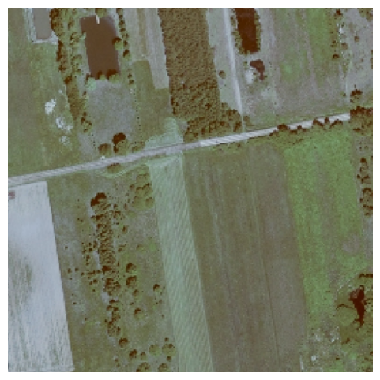

```python
plt.figure(figsize=[6,6])
plt.imshow(X[100])
plt.axis('off')
```

```
(-0.5, 255.5, 255.5, -0.5)
```

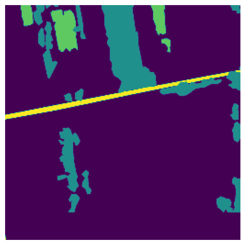

```python
plt.figure(figsize=[6,6])
plt.imshow(np.argmax(Y[100], axis=2))
plt.axis('off')
```

Now it's time to split the data into training and testing, rescaling the values to a range from 0 to 1:

```python
x_train, x_test, y_train, y_test = train_test_split(X, Y, test_size=0.3, random_state=10)
```

```python
del X, Y
```

```python
del list_img
```

```python
x_train = x_train/255
```

The next step is to import some keras and tensorflow functions for the FCN implementation:

```python
from keras.models import Model
from keras.regularizers import l2
from keras.layers import *
from keras.models import *
from tensorflow.keras import backend as K
import tensorflow as tf
#from tensorflow.keras.optimizers import Adam
#from tensorflow.keras.optimizers.legacy import Adam
from keras.optimizers import Adam
from tensorflow.keras.losses import Dice
```

This cell creates the BilinearUpsampling2D operation that will be used in the final part of the FCN architecture:

```python
def resize_images_bilinear(X, height_factor=1, width_factor=1, target_height=None, target_width=None, data_format='default'):
    '''Resizes the images contained in a 4D tensor of shape
    - [batch, channels, height, width] (for 'channels_first' data_format)
    - [batch, height, width, channels] (for 'channels_last' data_format)
    by a factor of (height_factor, width_factor). Both factors should be
    positive integers.
    '''
    if data_format == 'default':
        data_format = K.image_data_format()
    if data_format == 'channels_first':
        original_shape = K.int_shape(X)
        if target_height and target_width:
            new_shape = tf.constant(np.array((target_height, target_width)).astype('int32'))
        else:
            new_shape = tf.shape(X)[2:]
            new_shape *= tf.constant(np.array([height_factor, width_factor]).astype('int32'))
        X = permute_dimensions(X, [0, 2, 3, 1])
        X = tf.image.resize_bilinear(X, new_shape)
        X = permute_dimensions(X, [0, 3, 1, 2])
        if target_height and target_width:
            X.set_shape((None, None, target_height, target_width))
        else:
            X.set_shape((None, None, original_shape[2] * height_factor, original_shape[3] * width_factor))
        return X
    elif data_format == 'channels_last':
        original_shape = K.int_shape(X)
        if target_height and target_width:
            new_shape = tf.constant(np.array((target_height, target_width)).astype('int32'))
        else:
            new_shape = tf.shape(X)[1:3]
            new_shape *= tf.constant(np.array([height_factor, width_factor]).astype('int32'))
        X = tf.compat.v1.image.resize_bilinear(X, new_shape)
        if target_height and target_width:
            X.set_shape((None, target_height, target_width, None))
        else:
            X.set_shape((None, original_shape[1] * height_factor, original_shape[2] * width_factor, None))
        return X
    else:
        raise Exception('Invalid data_format: ' + data_format)

class BilinearUpSampling2D(Layer):
    def __init__(self, size=(1, 1), target_size=None, data_format='default', **kwargs):
        if data_format == 'default':
            data_format = K.image_data_format()
        self.size = tuple(size)
        if target_size is not None:
            self.target_size = tuple(target_size)
        else:
            self.target_size = None
        assert data_format in {'channels_last', 'channels_first'}, 'data_format must be in {tf, th}'
        self.data_format = data_format
        self.input_spec = [InputSpec(ndim=4)]
        super(BilinearUpSampling2D, self).__init__(**kwargs)

    def compute_output_shape(self, input_shape):
        if self.data_format == 'channels_first':
            width = int(self.size[0] * input_shape[2] if input_shape[2] is not None else None)
            height = int(self.size[1] * input_shape[3] if input_shape[3] is not None else None)
            if self.target_size is not None:
                width = self.target_size[0]
                height = self.target_size[1]
            return (input_shape[0],
                    input_shape[1],
                    width,
                    height)
        elif self.data_format == 'channels_last':
            width = int(self.size[0] * input_shape[1] if input_shape[1] is not None else None)
            height = int(self.size[1] * input_shape[2] if input_shape[2] is not None else None)
            if self.target_size is not None:
                width = self.target_size[0]
                height = self.target_size[1]
            return (input_shape[0],
                    width,
                    height,
                    input_shape[3])
        else:
            raise Exception('Invalid data_format: ' + self.data_format)

    def call(self, x, mask=None):
        if self.target_size is not None:
            return resize_images_bilinear(x, target_height=self.target_size[0], target_width=self.target_size[1], data_format=self.data_format)
        else:
            return resize_images_bilinear(x, height_factor=self.size[0], width_factor=self.size[1], data_format=self.data_format)

    def get_config(self):
        config = {'size': self.size, 'target_size': self.target_size}
        base_config = super(BilinearUpSampling2D, self).get_config()
        return dict(list(base_config.items()) + list(config.items()))
```

And then we can implement FCN:

```python
weight_decay = 0.
img_input = Input(shape=x_train.shape[1:])

# Block 1
x = Conv2D(64, (3, 3), activation='relu', padding='same', name='block1_conv1', kernel_regularizer=l2(weight_decay))(img_input)
x = Conv2D(64, (3, 3), activation='relu', padding='same', name='block1_conv2', kernel_regularizer=l2(weight_decay))(x)
x = MaxPooling2D((2, 2), strides=(2, 2), name='block1_pool')(x)

# Block 2
x = Conv2D(128, (3, 3), activation='relu', padding='same', name='block2_conv1', kernel_regularizer=l2(weight_decay))(x)
x = Conv2D(128, (3, 3), activation='relu', padding='same', name='block2_conv2', kernel_regularizer=l2(weight_decay))(x)
x = MaxPooling2D((2, 2), strides=(2, 2), name='block2_pool')(x)

# Block 3
x = Conv2D(256, (3, 3), activation='relu', padding='same', name='block3_conv1', kernel_regularizer=l2(weight_decay))(x)
x = Conv2D(256, (3, 3), activation='relu', padding='same', name='block3_conv2', kernel_regularizer=l2(weight_decay))(x)
x = Conv2D(256, (3, 3), activation='relu', padding='same', name='block3_conv3', kernel_regularizer=l2(weight_decay))(x)
x = MaxPooling2D((2, 2), strides=(2, 2), name='block3_pool')(x)

# Block 4
x = Conv2D(512, (3, 3), activation='relu', padding='same', name='block4_conv1', kernel_regularizer=l2(weight_decay))(x)
x = Conv2D(512, (3, 3), activation='relu', padding='same', name='block4_conv2', kernel_regularizer=l2(weight_decay))(x)
x = Conv2D(512, (3, 3), activation='relu', padding='same', name='block4_conv3', kernel_regularizer=l2(weight_decay))(x)
x = MaxPooling2D((2, 2), strides=(2, 2), name='block4_pool')(x)

# Block 5
x = Conv2D(512, (3, 3), activation='relu', padding='same', name='block5_conv1', kernel_regularizer=l2(weight_decay))(x)
x = Conv2D(512, (3, 3), activation='relu', padding='same', name='block5_conv2', kernel_regularizer=l2(weight_decay))(x)
x = Conv2D(512, (3, 3), activation='relu', padding='same', name='block5_conv3', kernel_regularizer=l2(weight_decay))(x)
x = MaxPooling2D((2, 2), strides=(2, 2), name='block5_pool')(x)

# Convolutional layers transfered from fully-connected layers
x = Conv2D(4096, (7, 7), activation='relu', padding='same', name='fc1', kernel_regularizer=l2(weight_decay))(x)
x = Dropout(0.5)(x)
x = Conv2D(4096, (1, 1), activation='relu', padding='same', name='fc2', kernel_regularizer=l2(weight_decay))(x)
x = Dropout(0.5)(x)
#classifying layer
x = Conv2D(NCLASSES, (1, 1), kernel_initializer='he_normal', activation='softmax', padding='valid', strides=(1, 1), kernel_regularizer=l2(weight_decay))(x)

x = BilinearUpSampling2D(size=(32, 32))(x)

model = Model(img_input, x)
```

```python
model.compile(optimizer=Adam(learning_rate = 1e-5), loss = 'categorical_crossentropy', metrics=['accuracy'])
model.summary()
```

```
Model: "functional"
```

[output not shown]

```
 Total params: 134,281,029 (512.24 MB)
```

```
 Trainable params: 134,281,029 (512.24 MB)
```

```
 Non-trainable params: 0 (0.00 B)
```

```python
history = model.fit(x = x_train, y= y_train, batch_size=8, epochs=100, verbose=1, shuffle=True, validation_split=0.25)
```

After training, we will get the loss and accuracy curves:

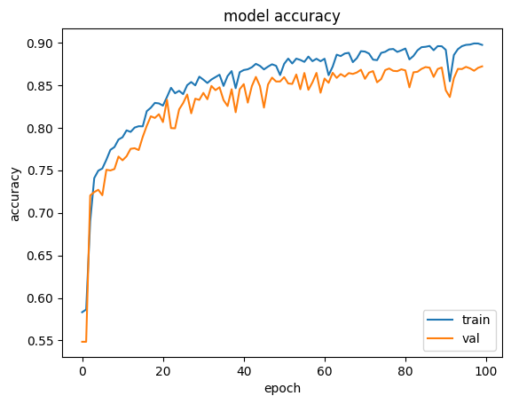

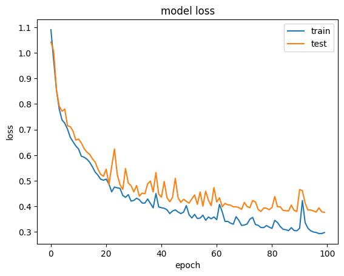

```python
plt.plot(history.history['accuracy'])
plt.plot(history.history['val_accuracy'])
plt.title('model accuracy')
plt.ylabel('accuracy')
plt.xlabel('epoch')
plt.legend(['train', 'val'], loc='lower right')
plt.show()

plt.plot(history.history['loss'])
plt.plot(history.history['val_loss'])
plt.title('model loss')
plt.ylabel('loss')
plt.xlabel('epoch')
plt.legend(['train', 'test'], loc='upper right')
plt.show()
```

So we can calculate the accuracy for the test set:

```python
del x_train, y_train
```

```python
x_test = x_test/255
```

```python
predict = model.predict(x_test)
```

```python
predict = np.round(predict)
```

```python
pred = np.argmax(predict, axis=3)
```

```python
true = np.argmax(y_test, axis=3)
```

```python
accuracy = accuracy_score(true.flatten(),pred.flatten())
print(accuracy)
```

```
0.8773271069918767
```

Finally, let's plot an example of the predicted result compared to the original mask:

```
(-0.5, 255.5, 255.5, -0.5)
```

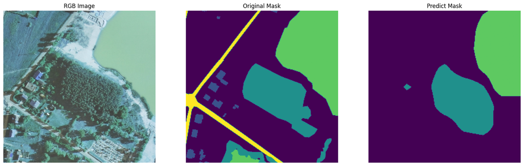

```python
i = 100
plt.figure(figsize=[20,8])
plt.subplot(131)
plt.imshow(x_test[i])
plt.title('RGB Image')
plt.axis('off')
plt.subplot(132)
plt.imshow(true[i], vmin=0,vmax=4)
plt.title('Original Mask')
plt.axis('off')
plt.subplot(133)
plt.imshow(pred[i], vmin=0,vmax=4)
plt.title('Predict Mask')
plt.axis('off')
```

## SegNet

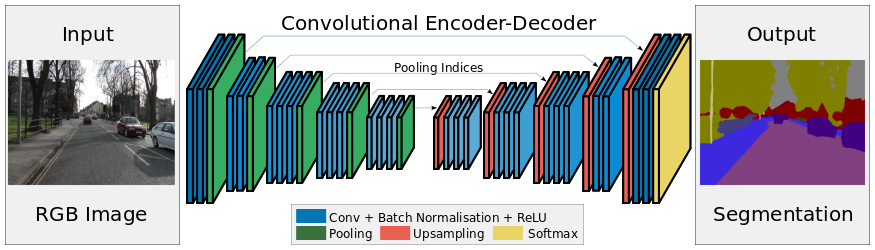

SegNet has an encoder network and a corresponding decoder network, followed by a final pixel-wise classification layer. This architecture is illustrated in the figure above. The encoder network consists of 13 convolutional layers that correspond to the first 13 convolutional layers in the VGG16 network designed for object classification. They discard the fully connected layers in favor of retaining higher resolution feature maps in the output of the deeper encoder. This also significantly reduces the number of parameters in the SegNet encoder network (from 134M to 14.7M) compared to other recent architectures. Each encoder layer has a corresponding decoder layer, and thus the decoder network has 13 layers. The final output of the decoder is fed to a multi-class soft-max classifier to produce class probabilities for each pixel independently.

The encoder network performs convolution with a filter bank to produce a set of feature maps. These are then batch normalized. Next, an element-wise rectified linear nonlinearity (ReLU) max(0, x) is applied. Next, max pooling with a 2 × 2 window and stride 2 (non-overlapping window) is performed and the resulting output is subsampled by a factor of 2. Max pooling is used to achieve translation invariance at small spatial offsets in the input image. Subsampling results in a large input image context (spatial window) for each pixel in the feature map. Although multiple layers of max pooling and subsampling can achieve more translation invariance for robust classification, correspondingly there is a loss of spatial resolution of the feature maps. The increasingly lossy image representation (contour detail) is not beneficial for segmentation where contour delineation is vital. Therefore, it is necessary to capture and store threshold information on the encoder feature maps before performing downsampling. If memory during inference is not constrained, all encoder feature maps (after downsampling) can be stored. This is often not the case in practical applications, and so we propose a more efficient way to store this information. It involves storing only the max-pooling indices, i.e., the locations of the maximum feature value in each pooling window are memorized for each encoder feature map. In principle, this can be done using 2 bits for each 2×2 pooling window, and is therefore much more efficient to store compared to memorizing the feature map(s) in floating precision.

The decoder network samples its input feature map using the memorized max pooling indices from the corresponding encoder feature map(s). This step produces sparse feature map(s). This SegNet decoding technique is illustrated in the figure below. These feature maps are then combined with a trainable decoder filter bank to produce dense feature maps. A batch normalization step is then applied to each of these maps. Note that the decoder corresponding to the first encoder (closest to the input image) produces a multi-channel feature map, even though its encoder input has 3 channels (RGB). This is different from the other decoders in the network, which produce feature maps with the same size and number of channels as their encoder inputs. The high-dimensional feature representation at the final decoder output is fed to a trainable soft-max classifier. This soft-max classifies each pixel independently. The output of the soft-max classifier is an image with K channel probabilities where K is the number of classes. The predicted segmentation corresponds to the class with maximum probability at each pixel.

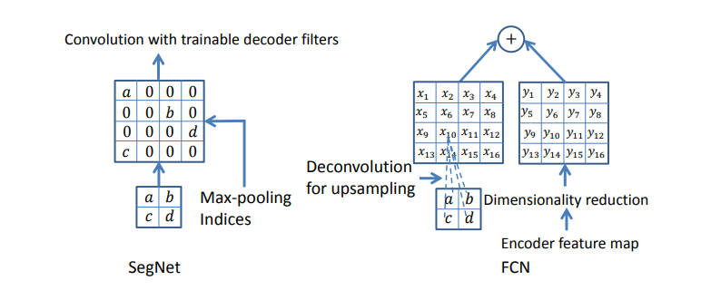

SegNet and FCN decoders. a, b, c, d correspond to values in a feature map. SegNet uses the max pooling indices to upsample (without learning) the feature map and convolves it with a trainable decoder filter bank. FCN upsamples by learning to deconvolve the input feature map and adds the corresponding encoder feature map to produce the decoder output. This feature map is the output of the max pooling layer (includes downsampling) in the corresponding encoder. Note that there are no trainable decoder filters in FCN.

This is the SegNet implementation:

```python
droprate = 0.1
pool_size = (2,2)
inputs = Input(shape=x_train.shape[1:])
conv_1 = Conv2D(32, (3, 3), kernel_initializer='he_uniform', padding='same')(inputs)
conv_1 = BatchNormalization()(conv_1)
conv_1 = Activation("relu")(conv_1)
conv_1 = Dropout(droprate)(conv_1)
conv_2 = Conv2D(32, (3, 3), kernel_initializer='he_uniform', padding='same')(conv_1)
conv_2 = BatchNormalization()(conv_2)
conv_2 = Activation("relu")(conv_2)


pool_1 = MaxPooling2D(pool_size=pool_size)(conv_2)

conv_3 = Conv2D(64, (3, 3), kernel_initializer='he_uniform', padding='same')(pool_1)
conv_3 = BatchNormalization()(conv_3)
conv_3 = Activation("relu")(conv_3)
conv_3 = Dropout(droprate)(conv_3)
conv_4 = Conv2D(64, (3, 3), kernel_initializer='he_uniform', padding='same')(conv_3)
conv_4 = BatchNormalization()(conv_4)
conv_4 = Activation("relu")(conv_4)


pool_2 = MaxPooling2D(pool_size=pool_size)(conv_4)

conv_5 = Conv2D(128, (3, 3), kernel_initializer='he_uniform', padding='same')(pool_2)
conv_5 = BatchNormalization()(conv_5)
conv_5 = Activation("relu")(conv_5)
conv_5 = Dropout(droprate)(conv_5)
conv_6 = Conv2D(128, (3, 3), kernel_initializer='he_uniform', padding='same')(conv_5)
conv_6 = BatchNormalization()(conv_6)
conv_6 = Activation("relu")(conv_6)
conv_6 = Dropout(droprate)(conv_6)
conv_7 = Conv2D(128, (3, 3), kernel_initializer='he_uniform', padding='same')(conv_6)
conv_7 = BatchNormalization()(conv_7)
conv_7 = Activation("relu")(conv_7)



pool_3 = MaxPooling2D(pool_size=pool_size)(conv_7)

conv_8 = Conv2D(256, (3, 3), kernel_initializer='he_uniform', padding='same')(pool_3)
conv_8 = BatchNormalization()(conv_8)
conv_8 = Activation("relu")(conv_8)
conv_8 = Dropout(droprate)(conv_8)
conv_9 = Conv2D(256, (3, 3), kernel_initializer='he_uniform', padding='same')(conv_8)
conv_9 = BatchNormalization()(conv_9)
conv_9 = Activation("relu")(conv_9)
conv_9 = Dropout(droprate)(conv_9)
conv_10 = Conv2D(256, (3, 3), kernel_initializer='he_uniform', padding='same')(conv_9)
conv_10 = BatchNormalization()(conv_10)
conv_10 = Activation("relu")(conv_10)



pool_4 = MaxPooling2D(pool_size=pool_size)(conv_10)


conv_11 = Conv2D(512, (3, 3), kernel_initializer='he_uniform', padding='same')(pool_4)
conv_11 = BatchNormalization()(conv_11)
conv_11 = Activation("relu")(conv_11)
conv_11 = Dropout(droprate)(conv_11)
conv_12 = Conv2D(512, (3, 3), kernel_initializer='he_uniform', padding='same')(conv_11)
conv_12 = BatchNormalization()(conv_12)
conv_12 = Activation("relu")(conv_12)
conv_12 = Dropout(droprate)(conv_12)
conv_13 = Conv2D(512, (3, 3), kernel_initializer='he_uniform', padding='same')(conv_12)
conv_13 = BatchNormalization()(conv_13)
conv_13 = Activation("relu")(conv_13)

pool_5 = MaxPooling2D(pool_size=pool_size)(conv_13)

unpool_1 = UpSampling2D(size=pool_size)(pool_5)

conv_14 = Conv2D(512, (3, 3), kernel_initializer='he_uniform', padding='same')(unpool_1)
conv_14 = BatchNormalization()(conv_14)
conv_14 = Activation("relu")(conv_14)
conv_14 = Dropout(droprate)(conv_14)
conv_15 = Conv2D(512, (3, 3), kernel_initializer='he_uniform', padding='same')(conv_14)
conv_15 = BatchNormalization()(conv_15)
conv_15 = Activation("relu")(conv_15)
conv_15 = Dropout(droprate)(conv_15)
conv_16 = Conv2D(256, (3, 3), kernel_initializer='he_uniform', padding='same')(conv_15)
conv_16 = BatchNormalization()(conv_16)
conv_16 = Activation("relu")(conv_16)

unpool_2 = UpSampling2D(size=pool_size)(conv_16)

conv_17 = Conv2D(256, (3, 3), kernel_initializer='he_uniform', padding='same')(unpool_2)
conv_17 = BatchNormalization()(conv_17)
conv_17 = Activation("relu")(conv_17)
conv_17 = Dropout(droprate)(conv_17)
conv_18 = Conv2D(256, (3, 3), kernel_initializer='he_uniform', padding='same')(conv_17)
conv_18 = BatchNormalization()(conv_18)
conv_18 = Activation("relu")(conv_18)
conv_18 = Dropout(droprate)(conv_18)
conv_19 = Conv2D(128, (3, 3), kernel_initializer='he_uniform', padding='same')(conv_18)
conv_19 = BatchNormalization()(conv_19)
conv_19 = Activation("relu")(conv_19)

unpool_3 = UpSampling2D(size=pool_size)(conv_19)


conv_20 = Conv2D(128, (3, 3), kernel_initializer='he_uniform', padding='same')(unpool_3)
conv_20 = BatchNormalization()(conv_20)
conv_20 = Activation("relu")(conv_20)
conv_20 = Dropout(droprate)(conv_20)
conv_21 = Conv2D(128, (3, 3), kernel_initializer='he_uniform', padding='same')(conv_20)
conv_21 = BatchNormalization()(conv_21)
conv_21 = Activation("relu")(conv_21)
conv_21 = Dropout(droprate)(conv_21)
conv_22 = Conv2D(64, (3, 3), kernel_initializer='he_uniform', padding='same')(conv_21)
conv_22 = BatchNormalization()(conv_22)
conv_22 = Activation("relu")(conv_22)


unpool_4 = UpSampling2D(size=pool_size)(conv_22)


conv_23 = Conv2D(64, (3, 3), kernel_initializer='he_uniform', padding='same')(unpool_4)
conv_23 = BatchNormalization()(conv_23)
conv_23 = Activation("relu")(conv_23)
conv_23 = Dropout(droprate)(conv_23)
conv_24 = Conv2D(32, (3, 3), kernel_initializer='he_uniform', padding='same')(conv_23)
conv_24 = BatchNormalization()(conv_24)
conv_24 = Activation("relu")(conv_24)


unpool_5 = UpSampling2D(size=pool_size)(conv_24)


conv_25 = Conv2D(32, (3, 3), kernel_initializer='he_uniform', padding='same')(unpool_5)
conv_25 = BatchNormalization()(conv_25)
conv_25 = Activation("relu")(conv_25)

conv_26 = Conv2D(NCLASSES, (1, 1), kernel_initializer='he_uniform', padding='same')(conv_25)
conv_26 = BatchNormalization()(conv_26)
outputs = Activation("softmax")(conv_26)


model = Model(inputs=inputs, outputs=outputs)

model.compile(optimizer=Adam(learning_rate=0.00001), loss = Dice, metrics=[ 'accuracy'])
model.summary()
```

[output not shown]

[output cut: 161 more lines]

[output not shown]

References:

https://nanonets.com/blog/how-to-do-semantic-segmentation-using-deep-learning/

https://nanonets.com/blog/semantic-image-segmentation-2020/

https://www.jeremyjordan.me/semantic-segmentation/

https://towardsdatascience.com/review-fcn-semantic-segmentation-eb8c9b50d2d1

https://www.meetshah.dev/semantic-segmentation/deep-learning/pytorch/visdom/2017/06/01/semantic-segmentation-over-the-years.html

http://ronny.rest/tutorials/module/seg_01/segmentation_04_training/

https://github.com/ykamikawa/tf-keras-SegNet/blob/master/model.py

https://ai-pool.com/m/segnet-1555409707

https://medium.com/analytics-vidhya/semantic-segmentation-in-pspnet-with-implementation-in-keras-4843d05fc025

https://www.kaggle.com/santhalnr/cityscapes-image-segmentation-pspnet

https://divamgupta.com/image-segmentation/2019/06/06/deep-learning-semantic-segmentation-keras.html